# BMIN-GA 1005 Programming for Data Analysis:Hypothesis Testing

Fred LaPolla

8/11/2024

```r
knitr::opts_chunk$set(echo = TRUE)
```

# Note on Presenting

How to knit your slides (demo)

# Hypothesis Testing

Tests to see if differences appear in groups we are analyzing.

Typically we want to see if the null hypothesis is true or can be rejected.

Results are termed in rejection of the null or failure to reject the null.

```r
nyc <-read.csv("https://raw.githubusercontent.com/fredlapolla/VilcekSummerDataAnalysis2024/main/NYC_HANES_DIAB.csv")

nyc$AGEGROUP <- factor(nyc$AGEGROUP, levels = 1:3, labels = c("Youngest", "Middle", "Aged"))
nyc$GENDER <- factor(nyc$GENDER, levels = 1:2, labels = c("male", "female"))
# Rename the HSQ_1 factor for identification
  nyc$HSQ_1 <- factor(nyc$HSQ_1, levels = 1:5, labels=c("Excellent","Very Good","Good", "Fair", "Poor"))
  # Rename the DX_DBTS as a factor
  nyc$DX_DBTS <- factor(nyc$DX_DBTS,levels = 1:3, labels=c("Diabetes with DX","Diabetes with no DX","No Diabetes"))
  #Diabetes dichotomy
  nyc$DBT_dichotomy <- ifelse(nyc$DX_DBTS == "No Diabetes", "NoDX", "DX")
  #hsq dichotomy
  nyc$HSQ_Dichotomy <- ifelse(nyc$HSQ_1 == "Excellent" | nyc$HSQ_1 == "Very Good", "VGood", "NotVGood")
```

# P Values

Important to note that a P value is just the odds of finding a result as “far” from the mean of the control group assuming the null hypothesis was true. So .05 means that only 5% of the time we would assume a result as far from the control group’s mean assuming there is no difference.

This is important because in data like RNA Seq Analysis, we may have 1000s of rows, simply see which results are significant at .05 is **Not** going to be meaningful.

**Remember** a P value < .05, does not mean either that your finding is “true” and it definitely does not mean it is biologically or scientifically significant.

A p value should be only one part of a broader context, including confidence intervals and honest assessment of how likely the findings were in the first place.

There is an on-going push among statisticians to de-emphasize the p value.

If you have a very small p in r, you get a value like “p-value < 2.2e-16” but for publishing you should write something like “p < .001”

# Contingency tables and Chi Squared X^2

Used for assessing if the proportions of of nominal (factor) variables are what we would expect if the groups were equal of not.

Chi square assumes > 5 observations per cell. Null hypothesis is that rows and columns are independent. It is easier to interpret a 2x2 square:

```r
chisq.test(nyc$HSQ_Dichotomy, nyc$DBT_dichotomy)
```

```
##
##  Pearson's Chi-squared test with Yates' continuity correction
##
## data:  nyc$HSQ_Dichotomy and nyc$DBT_dichotomy
## X-squared = 68.025, df = 1, p-value < 2.2e-16
```

# Odds Ratio

The most common effect measurement is the odds ratio, which would be dividing the group that has some exposure by those that did not. This would mean for a 2x2 table:

Number of having a Excellent or Very Good health with diabetes/Number of Excellent or Very Good Health health without diabetes

Divided by

Number of Not very good health with Diabetes/Number of Not very good health without diabetes

|a | b | |c | d |

(a/b)/(c/d)

Odds of 1 mean no difference, 0:.9999999 means the odds are lower in a group and 1.000000001: infinity mean the odds are higher

Conveniently there is a package called “epitools” that can calculate an oddsratio:

```r
#install.packages("epitools")
library(epitools)
oddsratio(nyc$HSQ_Dichotomy, nyc$DBT_dichotomy)
```

```
## $data
##           Outcome
## Predictor   DX NoDX Total
##   NotVGood 156  513   669
##   VGood     36  541   577
##   Total    192 1054  1246
##
## $measure
##           odds ratio with 95% C.I.
## Predictor  estimate    lower    upper
##   NotVGood 1.000000       NA       NA
##   VGood    4.550269 3.139152 6.761174
##
## $p.value
##           two-sided
## Predictor  midp.exact fisher.exact   chi.square
##   NotVGood         NA           NA           NA
##   VGood             0 7.481636e-18 8.334103e-17
##
## $correction
## [1] FALSE
##
## attr(,"method")
## [1] "median-unbiased estimate & mid-p exact CI"
```

# Adding contingency tables

Typically we will also want to see the actual tables. Creating a table will show us the total nubers, prop.table will tell us the percentage by either row (setting the margin to 1) or column (setting the margin to 2)

```r
HSQDxTable <- table(nyc$HSQ_Dichotomy, nyc$DBT_dichotomy)
HSQDxTable
```

```
##
##             DX NoDX
##   NotVGood 156  513
##   VGood     36  541
```

```r
 # Proportions of Age by DX per row
 prop.table(HSQDxTable, 1)
```

```
##
##                    DX       NoDX
##   NotVGood 0.23318386 0.76681614
##   VGood    0.06239168 0.93760832
```

```r
 # Proportions of Age by DX per column
 prop.table(HSQDxTable, 2)
```

```
##
##                   DX      NoDX
##   NotVGood 0.8125000 0.4867173
##   VGood    0.1875000 0.5132827
```

```r
chisq.test(nyc$HSQ_Dichotomy, nyc$DBT_dichotomy)
```

```
##
##  Pearson's Chi-squared test with Yates' continuity correction
##
## data:  nyc$HSQ_Dichotomy and nyc$DBT_dichotomy
## X-squared = 68.025, df = 1, p-value < 2.2e-16
```

```r
oddsratio(HSQDxTable)
```

```
## $data
##
##             DX NoDX Total
##   NotVGood 156  513   669
##   VGood     36  541   577
##   Total    192 1054  1246
##
## $measure
##           odds ratio with 95% C.I.
##            estimate    lower    upper
##   NotVGood 1.000000       NA       NA
##   VGood    4.550269 3.139152 6.761174
##
## $p.value
##           two-sided
##            midp.exact fisher.exact   chi.square
##   NotVGood         NA           NA           NA
##   VGood             0 7.481636e-18 8.334103e-17
##
## $correction
## [1] FALSE
##
## attr(,"method")
## [1] "median-unbiased estimate & mid-p exact CI"
```

# Contingency test with small values

For small n (less than 5 observations in a cell), the test for fisher’s exact test is:

fisher.test()

# On your own

Make a contingency table of HSQ1 vs a dichotomized Has or does not have diabetes. Run a chi square test and calculate the Odds Ratio.

# Parametric Tests

Parametric tests assume normality of our data.

We can visually assess this with histograms. We can also use the Sharpiro-Wilk test that comes in pastecs::stat.desc(norm = TRUE) to see a p value for if the data is normal

```r
library(pastecs)
stat.desc(nyc$UCREATININE, norm = TRUE)
```

```
##      nbr.val     nbr.null       nbr.na          min          max        range
## 1.449000e+03 0.000000e+00 7.800000e+01 1.000000e+00 6.120000e+02 6.110000e+02
##          sum       median         mean      SE.mean CI.mean.0.95          var
## 2.017080e+05 1.270000e+02 1.392050e+02 2.282999e+00 4.478340e+00 7.552312e+03
##      std.dev     coef.var     skewness     skew.2SE     kurtosis     kurt.2SE
## 8.690404e+01 6.242884e-01 1.005749e+00 7.822884e+00 1.469516e+00 5.718997e+00
##   normtest.W   normtest.p
## 9.405703e-01 1.178208e-23
```

We can also run this test on its own:

```r
shapiro.test(nyc$CHOLESTEROLTOTAL)
```

```
##
##  Shapiro-Wilk normality test
##
## data:  nyc$CHOLESTEROLTOTAL
## W = 0.98507, p-value = 9.615e-10
```

The normtest.p test tells us if data is likely to differ significantly from a normal distribution. p < .05 means it is not normally distributed, but a caveat is that very large sets of data will often have a “significant” p value since they are powered to detect very small differences.

We can also run the Kolmogorov-Smirnov Test:

```r
ks.test(nyc$CHOLESTEROLTOTAL, pnorm, mean(nyc$CHOLESTEROLTOTAL, na.rm = TRUE), sd(nyc$CHOLESTEROLTOTAL, na.rm = TRUE))
```

```
##
##  Asymptotic one-sample Kolmogorov-Smirnov test
##
## data:  nyc$CHOLESTEROLTOTAL
## D = 0.042812, p-value = 0.02476
## alternative hypothesis: two-sided
```

# Homogenity of Variance

We also want to test the assumption of homogeneity of variance. This basically means that at all levels going up of a variable, the amount of variation remains consistently the same. For example, we would want to know if the amount of variation in, say, cholesterol, was similar in diabetics and non-diabetics to compare. We can test this with a command called

leveneTest(VariableOfInterest, groups, center = median/mean)

```r
library(car)
leveneTest(nyc$CHOLESTEROLTOTAL, nyc$GENDER, center = mean)
```

```
## Levene's Test for Homogeneity of Variance (center = mean)
##         Df F value Pr(>F)
## group    1  0.0273 0.8688
##       1196
```

Like with the Shapiro-Wilk, a significant p < .05 means this does not match the assumption of equality of variance.

# T Test

T Test is used for comparing the means between two normally distributed groups. The null hypothesis says there is no difference between means of the groups.

First we will review assessing normality.

```r
par(mfrow = c(1,2))
library(psych)
library(dplyr)
```

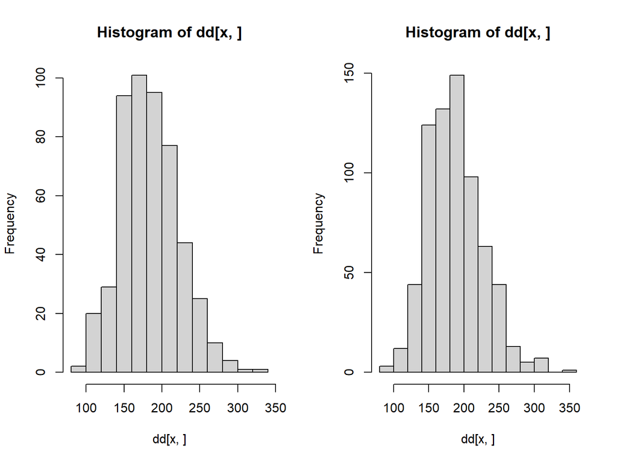

```
## nyc$GENDER: male
## $breaks
##  [1]  80 100 120 140 160 180 200 220 240 260 280 300 320 340
##
## $counts
##  [1]   2  20  29  94 101  95  77  44  25  10   4   1   1
##
## $density
##  [1] 1.988072e-04 1.988072e-03 2.882704e-03 9.343936e-03 1.003976e-02
##  [6] 9.443340e-03 7.654076e-03 4.373757e-03 2.485089e-03 9.940358e-04
## [11] 3.976143e-04 9.940358e-05 9.940358e-05
##
## $mids
##  [1]  90 110 130 150 170 190 210 230 250 270 290 310 330
##
## $xname
## [1] "dd[x, ]"
##
## $equidist
## [1] TRUE
##
## attr(,"class")
## [1] "histogram"
## ------------------------------------------------------------
## nyc$GENDER: female
## $breaks
##  [1]  80 100 120 140 160 180 200 220 240 260 280 300 320 340 360
##
## $counts
##  [1]   3  12  44 124 132 149  98  63  44  13   5   7   0   1
##
## $density
##  [1] 2.158273e-04 8.633094e-04 3.165468e-03 8.920863e-03 9.496403e-03
##  [6] 1.071942e-02 7.050360e-03 4.532374e-03 3.165468e-03 9.352518e-04
## [11] 3.597122e-04 5.035971e-04 0.000000e+00 7.194245e-05
##
## $mids
##  [1]  90 110 130 150 170 190 210 230 250 270 290 310 330 350
##
## $xname
## [1] "dd[x, ]"
##
## $equidist
## [1] TRUE
##
## attr(,"class")
## [1] "histogram"
```

```r
by( nyc$CHOLESTEROLTOTAL,nyc$GENDER, hist)
```

```r
psych::describe(nyc$CHOLESTEROLTOTAL)
```

```
##    vars    n   mean    sd median trimmed   mad min max range skew kurtosis   se
## X1    1 1198 186.48 38.69    183  184.67 38.55  95 357   262 0.51     0.44 1.12
```

```r
femChol <- nyc %>% filter(GENDER == "female")
maleChol <- nyc %>% filter(GENDER == "male")
psych::describe(femChol$CHOLESTEROLTOTAL)
```

```
##    vars   n   mean    sd median trimmed   mad min max range skew kurtosis   se
## X1    1 695 188.02 38.94    184  186.05 38.55  95 357   262 0.56     0.54 1.48
```

```r
psych::describe(maleChol$CHOLESTEROLTOTAL)
```

```
##    vars   n   mean    sd median trimmed   mad min max range skew kurtosis   se
## X1    1 503 184.36 38.27    181  182.79 37.06  98 335   237 0.44     0.24 1.71
```

```r
## close enough for the demo
```

# T-Tests

Now to actually do the T-Test: t.test compares the means. If we are comparing two objects, such as two columns, the notation is t.test(varA **,** VarB). If we are comparing some column by some variable (like cholesterol by sex) we would use the tilde:

```r
t.test(nyc$CHOLESTEROLTOTAL ~ nyc$GENDER)
```

```
##
##  Welch Two Sample t-test
##
## data:  nyc$CHOLESTEROLTOTAL by nyc$GENDER
## t = -1.6214, df = 1092.5, p-value = 0.1052
## alternative hypothesis: true difference in means between group male and group female is not equal to 0
## 95 percent confidence interval:
##  -8.0878295  0.7690029
## sample estimates:
##   mean in group male mean in group female
##             184.3579             188.0173
```

In R, if you set var.equal = FALSE, R automatically checks the variances to see if they are equal and “decides” to run the student vs Welch test based on if they are equal or not, so you can leave as False.

```r
t.test(femChol$CHOLESTEROLTOTAL, maleChol$CHOLESTEROLTOTAL, paired = FALSE, alternative = "two.sided", conf.level = 0.95, var.equal = FALSE)
```

```
##
##  Welch Two Sample t-test
##
## data:  femChol$CHOLESTEROLTOTAL and maleChol$CHOLESTEROLTOTAL
## t = 1.6214, df = 1092.5, p-value = 0.1052
## alternative hypothesis: true difference in means is not equal to 0
## 95 percent confidence interval:
##  -0.7690029  8.0878295
## sample estimates:
## mean of x mean of y
##  188.0173  184.3579
```

Things to note, paired is set to false. Paired would mean they were the same people/subjects. So for example if we weighed people at the start of a test, then put them on a diet and weighed at the end, that would be paired. Here the male and female groups are totally separate people.

The tails “alternative” is two.sided. It could be lesser or greater if we were doing a single tailed test, but this is less common.

# On Your Own

Try comparing mean LDL by if a person has diabetes or not. To do this you will need to:

1. Collapse Diabetes into two groups
2. Check that LDL Estimate appears normally distributed
3. Run a T Test.

# Non-Parametric Tests for Comparing Medians

### Mann-Whitney (unpaired) and Wilcoxon (paired)

If we have a small sample under 30 (which in this case we have a large sample) and non-normally distributed data we may need to choose a non-parametric test.

**Confusing note:** Both of these are called wilcox.test() in R, and we then set an argument to be paired = TRUE or FALSE.

Remember paired means they are the same subjects before and after, unpaired means they are separate.

Also non-parametric means not normally distributed. Outliers will throw off t-tests and parametric tests.

```r
## Because paired = False, technically this is a Mann-Whitney test
wilcox.test( nyc$COTININE ~ nyc$GENDER, paired = FALSE)
```

```
##
##  Wilcoxon rank sum test with continuity correction
##
## data:  nyc$COTININE by nyc$GENDER
## W = 185928, p-value = 0.03192
## alternative hypothesis: true location shift is not equal to 0
```

If these were before and after data, we could perform the Wilcoxon test by setting paired = TRUE.

# On Your Own

Try comparing the means of A1C in diabetics to non-diabetics. What command will you use, and which arguments will it take?

# Correlations

### Pearson’ R (parametric), Spearman Rho (non-parametric), Kendall’s Tau (non-parametric)

There are several options: cor(), cor.test() and rcorr(). Cor does not provide a confidence interval or P Value, but can do multiple correlations. Rcorr() requires a matrix and does not calculte Kendall’s Tau.

Note here we are doing cor.test(), but when we made heatmaps we did just cor(). The difference is cor.test provides the 95% confidence intervals and a p value, as well as the pearson’s R or spearman’s Rho, where cor just provides R/Rho.

```r
cor.test(nyc$CHOLESTEROLTOTAL, nyc$SPAGE, method = "pearson")
```

```
##
##  Pearson's product-moment correlation
##
## data:  nyc$CHOLESTEROLTOTAL and nyc$SPAGE
## t = 6.6881, df = 1196, p-value = 3.463e-11
## alternative hypothesis: true correlation is not equal to 0
## 95 percent confidence interval:
##  0.1346847 0.2438873
## sample estimates:
##       cor
## 0.1898731
```

We can then square the R result. This gives us an estimate of how much the variability in the outcome is shared by the other correlating variable. This is often expressed as how much variation is accounted for by the other variable.

# Non-Parametric: Spearman’s Rho

```r
cor.test(nyc$GLUCOSE, nyc$A1C, method = "spearman")
```

```
##
##  Spearman's rank correlation rho
##
## data:  nyc$GLUCOSE and nyc$A1C
## S = 153535271, p-value < 2.2e-16
## alternative hypothesis: true rho is not equal to 0
## sample estimates:
##       rho
## 0.4533381
```

# Non-Parametric: Kendall’s Tau

Kendall’s Tau is more appropriate for smaller data

# On Your Own

Run a correlation of lead to to total mercury. Which test will you choose and why? What results do you get?

# Power Assessment

Assessing power will help readers of your research to know the likelihood of type II error (saying there is not a difference when in fact one exists). Underpowered studies are a major problem in pre-clinical research that limit the replicability of findings. It is best to be transparent about providing a power calculation so that readers will know if results need to be confirmed with larger studies.

Check out the information provided by Stat Methods on using the pwr package for power tests for different common hypothesis tests: https://www.statmethods.net/stats/power.html

```r
library(pwr)
pwr.t.test(n=450  , d =0.1194496 , sig.level =0.05, type = "two.sample", alternative=("two.sided"))
```

```
##
##      Two-sample t test power calculation
##
##               n = 450
##               d = 0.1194496
##       sig.level = 0.05
##           power = 0.43254
##     alternative = two.sided
##
## NOTE: n is number in *each* group
```

```r
pwr.t.test( d = 0.1194496 , sig.level = 0.05, power = 0.8, type = "two.sample", alternative=("two.sided"))
```

```
##
##      Two-sample t test power calculation
##
##               n = 1101.15
##               d = 0.1194496
##       sig.level = 0.05
##           power = 0.8
##     alternative = two.sided
##
## NOTE: n is number in *each* group
```